# Weather and Corn Yield Regressions

Bri Rick

3/3/2022

## Weather Data Analysis

### Load the PRISM daily maximum temperatures

```r
# daily max temperature
# dimensions: counties x days x years
prism <- readMat("data/prismiowa.mat")

# look at county #1
t_1981_c1 <- prism$tmaxdaily.iowa[1,,1]
t_1981_c1[366]
```

```
## [1] NaN
```

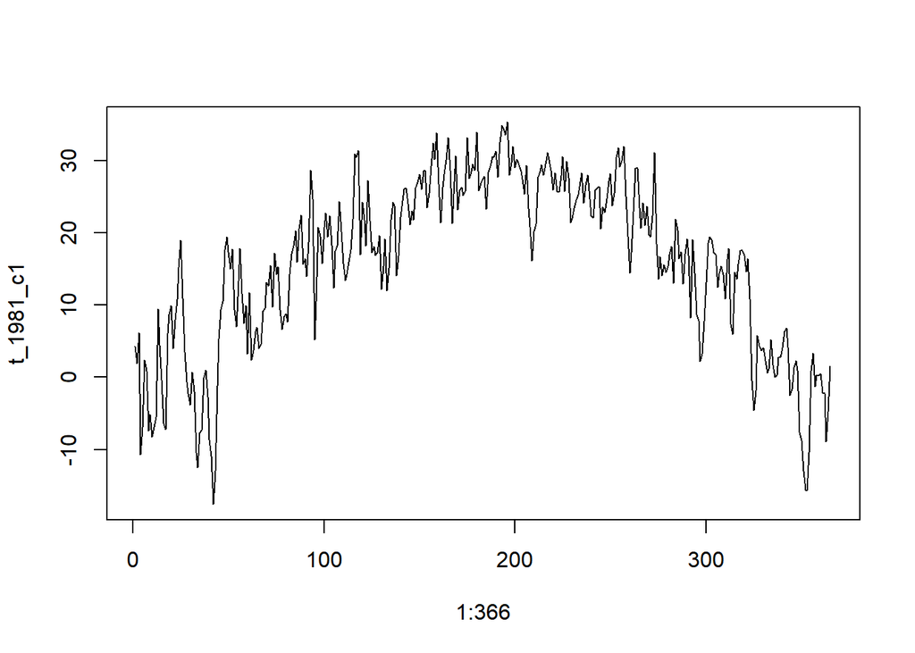

```r
plot(1:366, t_1981_c1, type = "l")
```

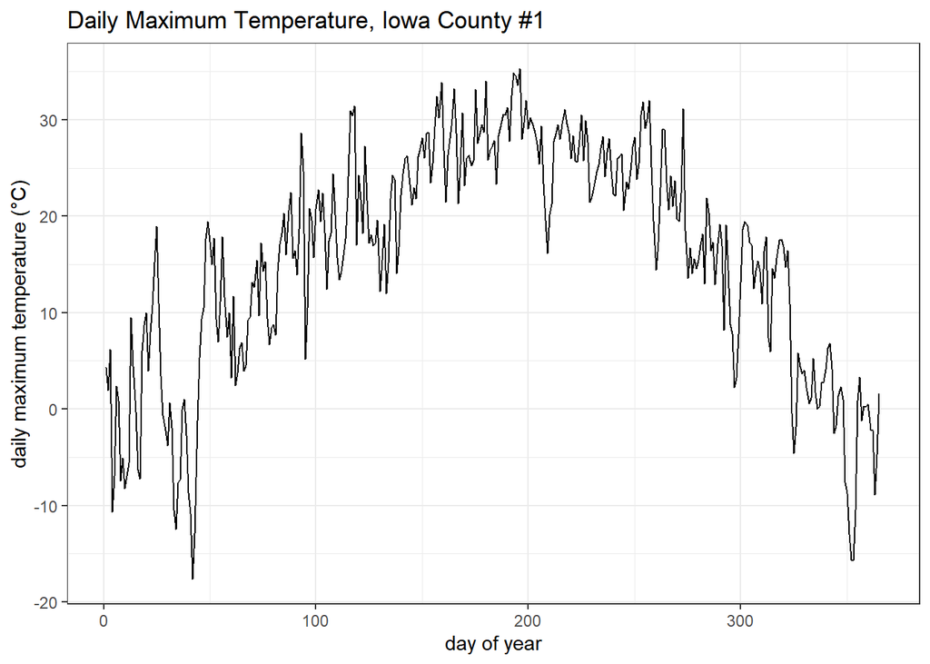

```r
ggplot() +
  geom_line(mapping = aes(x=1:366, y = t_1981_c1)) +
  theme_bw() +
  xlab("day of year") +
  ylab("daily maximum temperature (°C)") +
  ggtitle("Daily Maximum Temperature, Iowa County #1")
```

```r
# assign dimension names to tmax matrix
dimnames(prism$tmaxdaily.iowa) <- list(prism$COUNTYFP, 1:366, prism$years)

# converted 3d matrix into a data frame
tmaxdf <- as.data.frame.table(prism$tmaxdaily.iowa)

# relabel the columns
colnames(tmaxdf) <- c("countyfp","doy","year","tmax")
tmaxdf <- tibble(tmaxdf)
```

## Temperature trends

### Summer temperature trends: Winneshiek County

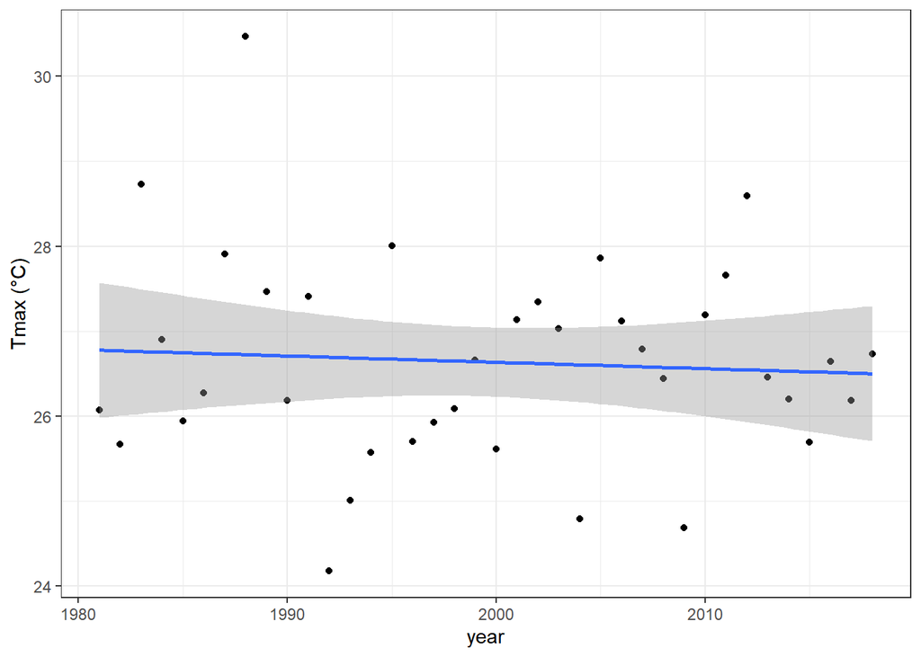

```r
tmaxdf$doy <- as.numeric(tmaxdf$doy)
tmaxdf$year <- as.numeric(as.character(tmaxdf$year))

winnesummer <- tmaxdf %>%
  filter(countyfp==191 & doy >= 152 & doy <= 243) %>%
  group_by(year) %>%
  summarize(meantmax = mean(tmax))

ggplot(winnesummer, mapping = aes(x = year, y = meantmax)) +
  geom_point() +
  theme_bw() +
  labs(x = "year", y = "Tmax (°C)") +
  geom_smooth(method = lm)
```

```r
lm_summertmax <- lm(meantmax ~ year, winnesummer)
summary(lm_summertmax)
```

```
##
## Call:
## lm(formula = meantmax ~ year, data = winnesummer)
##
## Residuals:
##     Min      1Q  Median      3Q     Max
## -2.5189 -0.7867 -0.0341  0.6859  3.7415
##
## Coefficients:
##             Estimate Std. Error t value Pr(>|t|)
## (Intercept) 41.57670   36.44848   1.141    0.262
## year        -0.00747    0.01823  -0.410    0.684
##
## Residual standard error: 1.232 on 36 degrees of freedom
## Multiple R-squared:  0.004644,   Adjusted R-squared:  -0.02301
## F-statistic: 0.168 on 1 and 36 DF,  p-value: 0.6844
```

### Winter Temperatures - Winneshiek County

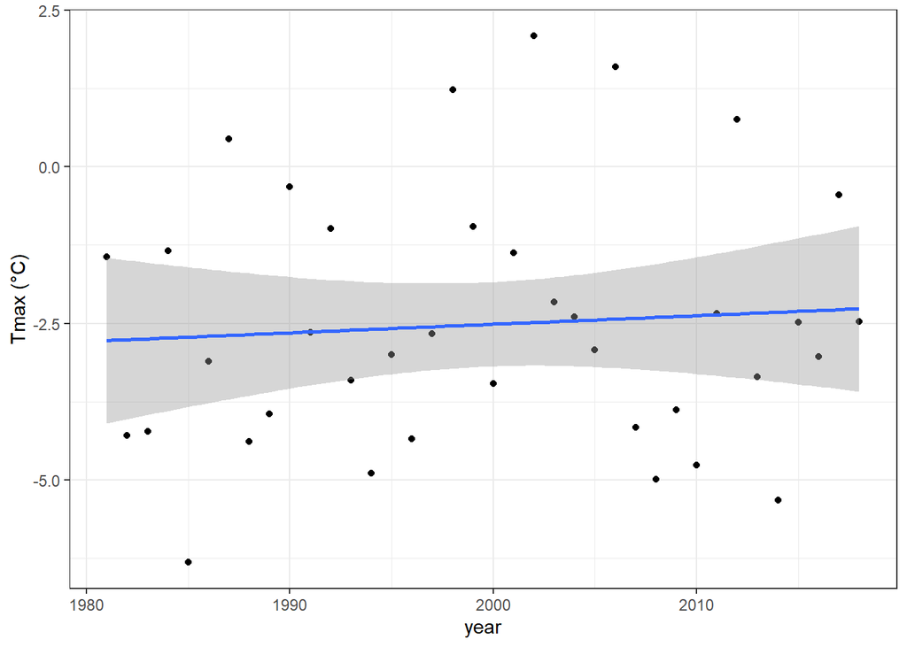

```r
winnewinter <- tmaxdf %>%
  filter(countyfp==191 & (doy <= 59 | doy >= 335) & !is.na(tmax)) %>%
  group_by(year) %>%
  summarize(meantmax = mean(tmax))

ggplot(winnewinter, mapping = aes(x = year, y = meantmax)) +
  geom_point() +
  theme_bw() +
  labs(x = "year", y = "Tmax (°C)") +
  geom_smooth(method = lm)
```

```r
lm_wintertmax <- lm(meantmax ~ year, winnewinter)
summary(lm_wintertmax)
```

```
##
## Call:
## lm(formula = meantmax ~ year, data = winnewinter)
##
## Residuals:
##     Min      1Q  Median      3Q     Max
## -3.5978 -1.4917 -0.3053  1.3778  4.5709
##
## Coefficients:
##              Estimate Std. Error t value Pr(>|t|)
## (Intercept) -29.87825   60.48100  -0.494    0.624
## year          0.01368    0.03025   0.452    0.654
##
## Residual standard error: 2.045 on 36 degrees of freedom
## Multiple R-squared:  0.005652,   Adjusted R-squared:  -0.02197
## F-statistic: 0.2046 on 1 and 36 DF,  p-value: 0.6537
```

### Multiple regression – Quadratic time trend

```r
winnewinter$yearsq <- winnewinter$year^2

lm_wintertmaxquad <- lm(meantmax ~ year + yearsq, winnewinter)
summary(lm_wintertmaxquad)
```

```
##
## Call:
## lm(formula = meantmax ~ year + yearsq, data = winnewinter)
##
## Residuals:
##     Min      1Q  Median      3Q     Max
## -3.3539 -1.2985 -0.2813  1.4055  4.2620
##
## Coefficients:
##               Estimate Std. Error t value Pr(>|t|)
## (Intercept) -1.086e+04  1.238e+04  -0.877    0.386
## year         1.085e+01  1.239e+01   0.876    0.387
## yearsq      -2.710e-03  3.097e-03  -0.875    0.388
##
## Residual standard error: 2.051 on 35 degrees of freedom
## Multiple R-squared:  0.02694,    Adjusted R-squared:  -0.02867
## F-statistic: 0.4845 on 2 and 35 DF,  p-value: 0.6201
```

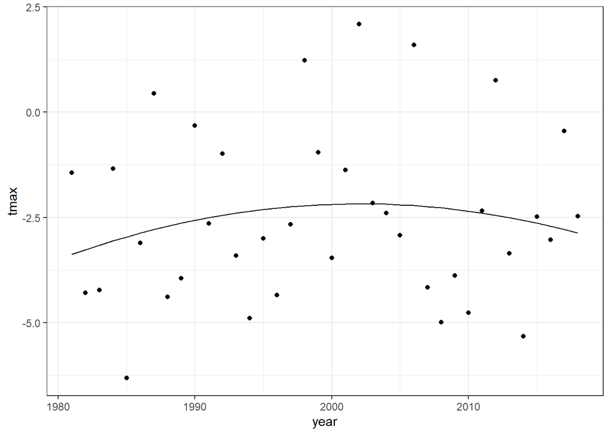

```r
winnewinter$fitted <- lm_wintertmaxquad$fitted.values

ggplot(winnewinter) +
  geom_point(mapping = aes(x = year, y = meantmax)) +
  geom_line(mapping = aes(x = year, y = fitted)) +
  theme_bw() +
  labs(x = "year", y = "tmax")
```

### Download NASS corn yield data

```r
# set our API key with NASS
nassqs_auth(key = "F7506B86-1C9E-39F3-AA20-719CAD3B47A3")

# parameters to query on
params <- list(commodity_desc = "CORN", util_practice_desc = "GRAIN", prodn_practice_desc = "ALL PRODUCTION PRACTICES", year__GE = 1981, state_alpha = "IA")

# download
cornyieldsall <- nassqs_yields(params)
cornyieldsall$county_ansi <- as.numeric(cornyieldsall$county_ansi)
cornyieldsall$yield <- as.numeric(cornyieldsall$Value)

# clean and filter this dataset
cornyields <- select(cornyieldsall, county_ansi, county_name, yield, year) %>%
  filter(!is.na(county_ansi) & !is.na(yield))
cornyields <- tibble(cornyields)
```

## Assignment

### Question 1a: Extract Winneshiek County corn yields, fit a linear time trend, make a plot. Is there a significant time trend?

*Yes, there is a significant increase in corn yield over time for Winneshiek County, with an increase of about 2.46 per year.*

```r
cornWinn <- cornyields %>% filter(county_name == "WINNESHIEK")

lm_cornWinn <- lm(yield ~ year, cornWinn)
cornWinn$fitted <- lm_cornWinn$fitted.values
summary(lm_cornWinn)
```

```
##
## Call:
## lm(formula = yield ~ year, data = cornWinn)
##
## Residuals:
##     Min      1Q  Median      3Q     Max
## -51.163  -1.841   2.363   9.437  24.376
##
## Coefficients:
##              Estimate Std. Error t value Pr(>|t|)
## (Intercept) -4763.290    448.286  -10.63 4.46e-13 ***
## year            2.457      0.224   10.96 1.77e-13 ***
## ---
## Signif. codes:  0 '***' 0.001 '**' 0.01 '*' 0.05 '.' 0.1 ' ' 1
##
## Residual standard error: 16.97 on 39 degrees of freedom
## Multiple R-squared:  0.7551, Adjusted R-squared:  0.7488
## F-statistic: 120.2 on 1 and 39 DF,  p-value: 1.767e-13
```

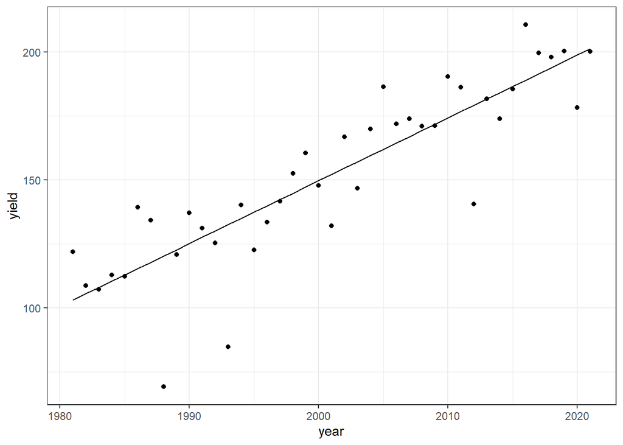

```r
ggplot(cornWinn) +
  geom_point(aes(x = year, y = yield)) +
  geom_line(aes(x = year, y = fitted)) +
  theme_bw()
```

### Question 1b: Fit a quadratic time trend (i.e., year + year^2) and make a plot. Is there evidence for slowing yield growth?

*There does not appear to be evidence for a slowing in yield growth in Winnesheik County in Iowa*

```r
cornWinn$yearsq <- cornWinn$year^2

lm_cornWinnquad <- lm(yield ~ year + yearsq, cornWinn)
summary(lm_cornWinnquad)
```

```
##
## Call:
## lm(formula = yield ~ year + yearsq, data = cornWinn)
##
## Residuals:
##     Min      1Q  Median      3Q     Max
## -51.384  -3.115   1.388   9.743  25.324
##
## Coefficients:
##               Estimate Std. Error t value Pr(>|t|)
## (Intercept)  2.583e+04  8.580e+04   0.301    0.765
## year        -2.812e+01  8.576e+01  -0.328    0.745
## yearsq       7.641e-03  2.143e-02   0.357    0.723
##
## Residual standard error: 17.17 on 38 degrees of freedom
## Multiple R-squared:  0.7559, Adjusted R-squared:  0.7431
## F-statistic: 58.84 on 2 and 38 DF,  p-value: 2.311e-12
```

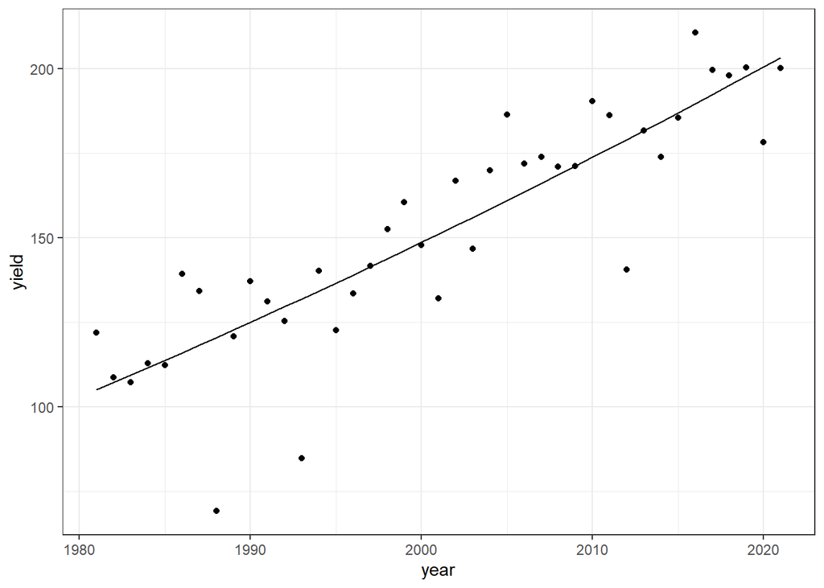

```r
cornWinn$fittedsq <- lm_cornWinnquad$fitted.values

ggplot(cornWinn) +
  geom_point(aes(x = year, y = yield)) +
  geom_line(aes(x = year, y = fittedsq)) +
  theme_bw()
```

### Question 2 – Time Series: Let’s analyze the relationship between temperature and yields for the Winneshiek County time series. Use data on yield and summer avg Tmax. Is adding year or Tmax^2 to your model helpful? Make a plot and interpret the results.

*Adding tmax^2 to the model is helpful and gives a better fit for the model.*

```r
tmaxyield <- cornWinn %>% inner_join(winnesummer, by = "year")
tmaxyield$tsq <- tmaxyield$meantmax^2

lm_tmaxyield <- lm(yield ~ meantmax, tmaxyield)
summary(lm_tmaxyield)
```

```
##
## Call:
## lm(formula = yield ~ meantmax, data = tmaxyield)
##
## Residuals:
##    Min     1Q Median     3Q    Max
## -71.96 -19.85  -3.19  24.64  61.72
##
## Coefficients:
##             Estimate Std. Error t value Pr(>|t|)
## (Intercept)  275.876    118.335   2.331   0.0255 *
## meantmax      -4.763      4.438  -1.073   0.2902
## ---
## Signif. codes:  0 '***' 0.001 '**' 0.01 '*' 0.05 '.' 0.1 ' ' 1
##
## Residual standard error: 32.88 on 36 degrees of freedom
## Multiple R-squared:  0.03101,    Adjusted R-squared:  0.004098
## F-statistic: 1.152 on 1 and 36 DF,  p-value: 0.2902
```

```r
tmaxyield$fitmeantmax <- lm_tmaxyield$fitted.values

lm_tmaxyieldyear <- lm(yield ~ meantmax + year, tmaxyield)
summary(lm_tmaxyieldyear)
```

```
##
## Call:
## lm(formula = yield ~ meantmax + year, data = tmaxyield)
##
## Residuals:
##     Min      1Q  Median      3Q     Max
## -53.071  -7.269   2.271   9.935  27.505
##
## Coefficients:
##              Estimate Std. Error t value Pr(>|t|)
## (Intercept) -4791.774    513.812  -9.326 5.10e-11 ***
## meantmax       -3.201      2.308  -1.387    0.174
## year            2.514      0.253   9.934 1.01e-11 ***
## ---
## Signif. codes:  0 '***' 0.001 '**' 0.01 '*' 0.05 '.' 0.1 ' ' 1
##
## Residual standard error: 17.06 on 35 degrees of freedom
## Multiple R-squared:  0.7463, Adjusted R-squared:  0.7318
## F-statistic: 51.48 on 2 and 35 DF,  p-value: 3.761e-11
```

```r
tmaxyield$fitmeantmaxyear <- lm_tmaxyieldyear$fitted.values

lm_tmaxyieldsq <- lm(yield ~ meantmax + tsq, tmaxyield)
summary(lm_tmaxyieldsq)
```

```
##
## Call:
## lm(formula = yield ~ meantmax + tsq, data = tmaxyield)
##
## Residuals:
##     Min      1Q  Median      3Q     Max
## -56.587 -22.262  -0.982  22.409  52.798
##
## Coefficients:
##              Estimate Std. Error t value Pr(>|t|)
## (Intercept) -4223.604   1446.639  -2.920  0.00609 **
## meantmax      328.918    107.068   3.072  0.00410 **
## tsq            -6.173      1.979  -3.119  0.00362 **
## ---
## Signif. codes:  0 '***' 0.001 '**' 0.01 '*' 0.05 '.' 0.1 ' ' 1
##
## Residual standard error: 29.5 on 35 degrees of freedom
## Multiple R-squared:  0.2417, Adjusted R-squared:  0.1984
## F-statistic: 5.579 on 2 and 35 DF,  p-value: 0.007887
```

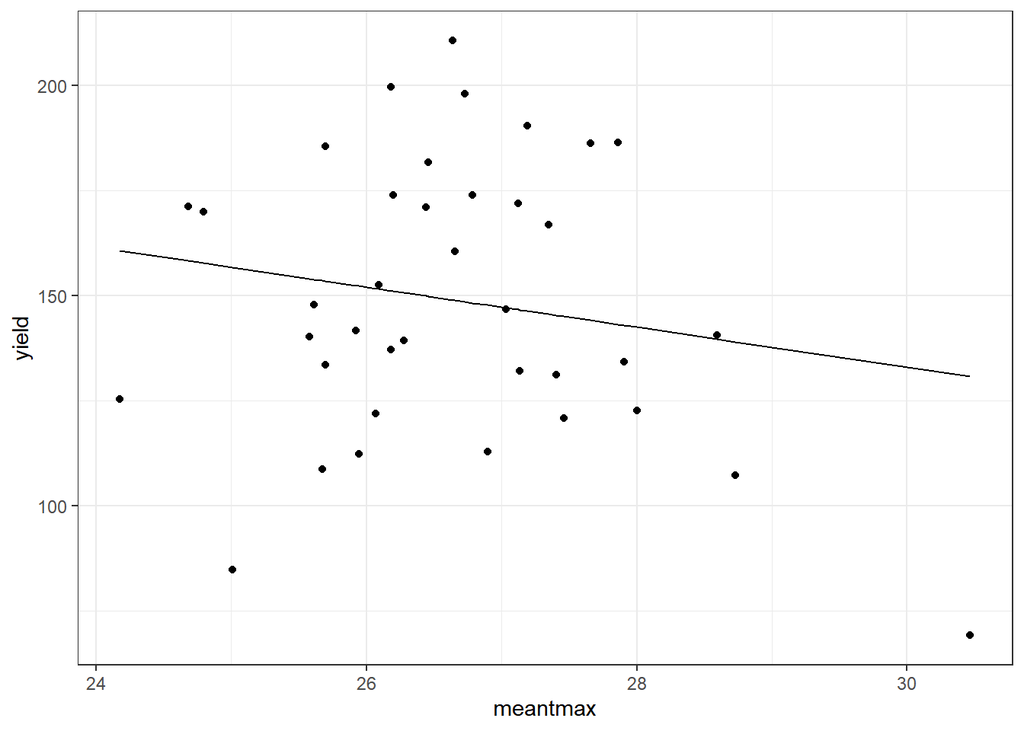

```r
tmaxyield$fitmeantmaxyield <- lm_tmaxyieldsq$fitted.values

ggplot(tmaxyield) +
  geom_point(aes(y = yield, x = meantmax)) +
  geom_line(aes(x = meantmax, y = fitmeantmax))+
  theme_bw()
```

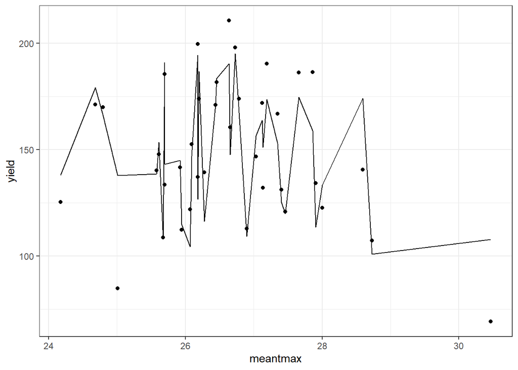

```r
ggplot(tmaxyield) +
  geom_point(aes(y = yield, x = meantmax)) +
  geom_line(aes(x = meantmax, y = fitmeantmaxyear))+
  theme_bw()
```

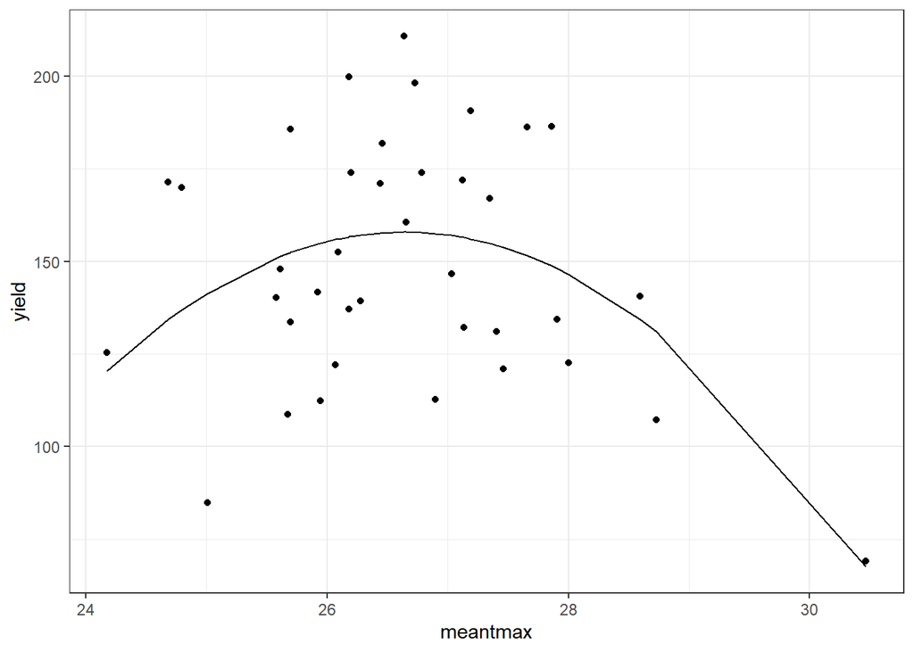

```r
ggplot(tmaxyield) +
  geom_point(aes(y = yield, x = meantmax)) +
  geom_line(aes(x = meantmax, y = fitmeantmaxyield))+
  theme_bw()
```

### Question 3 – Cross-Section: Analyze the relationship between temperature and yield across all counties in 2018. Is there a relationship? Interpret the results.

*There is an increase in yield with temperature until about 15 degrees C, then there is a decrease in yield with an increase in temperature. A simple linear model does not fit this trend well, however, a quadradic model incorporating mean T max and mean T max squared fits well.*

```r
cornyields18 <- cornyields %>% filter(year == 2018) %>%
  group_by(county_name)

tmax_county <- tmaxdf %>% group_by(countyfp) %>%
  filter(year == 2018) %>%
  filter(doy >- 152 & doy <= 243) %>%
  summarize(meantmax = mean(tmax)) %>%
  rename(county_ansi = "countyfp")

tmax_county$county_ansi <- as.numeric(as.character(tmax_county$county_ansi))

yield_county <- left_join(cornyields18, tmax_county, by = "county_ansi")
yield_county$tsq <- yield_county$meantmax^2

lm_counties <- lm(yield ~ meantmax, yield_county)
summary(lm_counties)
```

```
##
## Call:
## lm(formula = yield ~ meantmax, data = yield_county)
##
## Residuals:
##     Min      1Q  Median      3Q     Max
## -42.760 -14.824  -0.177  17.742  32.573
##
## Coefficients:
##             Estimate Std. Error t value Pr(>|t|)
## (Intercept) 208.2089    24.0554   8.655 1.66e-13 ***
## meantmax     -0.9727     1.5589  -0.624    0.534
## ---
## Signif. codes:  0 '***' 0.001 '**' 0.01 '*' 0.05 '.' 0.1 ' ' 1
##
## Residual standard error: 19.97 on 91 degrees of freedom
## Multiple R-squared:  0.00426,    Adjusted R-squared:  -0.006682
## F-statistic: 0.3893 on 1 and 91 DF,  p-value: 0.5342
```

```r
yield_county$fitted <- lm_counties$fitted.values

lm_countiessq <- lm(yield ~ meantmax + tsq, yield_county)
summary(lm_tmaxyieldsq)
```

[output not shown]

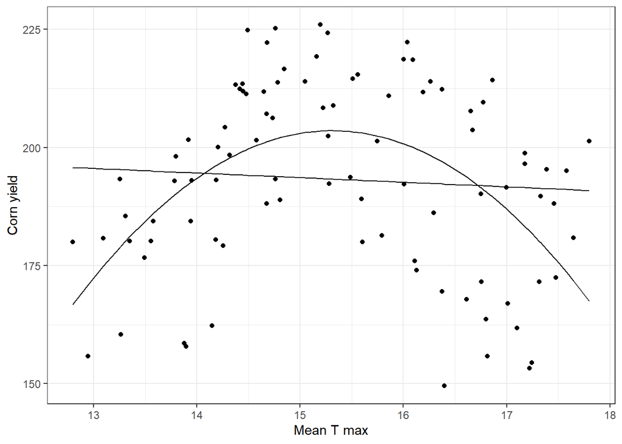

```r
yield_county$fitmeantmaxyield <- lm_countiessq$fitted.values

ggplot(yield_county) +
  geom_point(aes(x=meantmax, y = yield)) +
  geom_line(aes(x = meantmax, y = fitted)) +
  geom_line(aes(x = meantmax, y = fitmeantmaxyield)) +
  xlab("Mean T max")+
  ylab("Corn yield")+
  theme_bw()
```

### Question 4 – Panel: One way to leverage multiple time series is to group all data into what is called a “panel” regression. Convert the county ID code (“countyfp” or “county_ansi”) into factor using as.factor, then include this variable in a regression using all counties’ yield and summer temperature data. How does the significance of your temperature coefficients (Tmax, Tmax^2) change? Make a plot comparing actual and fitted yields and interpret the results of your model.

```r
cornyieldsall <- cornyields %>% group_by(county_ansi)

tmaxcountyall <- tmaxdf %>%  group_by(countyfp) %>%
  filter(doy >- 152 & doy <= 243) %>%
  summarize(meantmax = mean(tmax)) %>%
  rename(county_ansi = "countyfp")

tmaxcountyall$county_ansi <- as.numeric(as.character(tmaxcountyall$county_ansi))

panel <- left_join(cornyieldsall, tmaxcountyall, by = "county_ansi")

panel$county_ansi <- as.factor(panel$county_ansi)
panel$tsq <- panel$meantmax^2

lm_yield_county_combo <- lm(yield ~ meantmax + tsq + county_ansi + year, panel)
summary(lm_yield_county_combo)
```

```
##
## Call:
## lm(formula = yield ~ meantmax + tsq + county_ansi + year, data = panel)
##
## Residuals:
##      Min       1Q   Median       3Q      Max
## -101.016   -9.576    3.141   14.498   52.720
##
## Coefficients: (2 not defined because of singularities)
##                  Estimate Std. Error t value Pr(>|t|)
## (Intercept)    -5.338e+03  4.866e+02 -10.969  < 2e-16 ***
## meantmax        1.222e+02  6.252e+01   1.955 0.050657 .
## tsq            -4.109e+00  2.010e+00  -2.044 0.040992 *
## county_ansi3   -2.349e+00  5.050e+00  -0.465 0.641796
## county_ansi5   -6.749e+00  4.301e+00  -1.569 0.116669
## county_ansi7   -1.501e+01  5.374e+00  -2.793 0.005246 **
## county_ansi9    7.814e-01  4.568e+00   0.171 0.864175
## county_ansi11  -3.179e+00  4.988e+00  -0.637 0.523956
## county_ansi13  -3.745e+00  4.879e+00  -0.768 0.442754
## county_ansi15   6.265e+00  4.745e+00   1.320 0.186831
## county_ansi17   7.945e-01  4.629e+00   0.172 0.863735
## county_ansi19  -1.987e+00  4.727e+00  -0.420 0.674257
## county_ansi21  -2.165e+00  4.934e+00  -0.439 0.660751
## county_ansi23  -1.595e+00  4.866e+00  -0.328 0.743144
## county_ansi25   9.570e-02  5.004e+00   0.019 0.984741
## county_ansi27   1.597e+00  4.836e+00   0.330 0.741197
## county_ansi29   6.733e+00  4.680e+00   1.439 0.150329
## county_ansi31   6.957e+00  4.813e+00   1.446 0.148369
## county_ansi33  -5.065e+00  4.181e+00  -1.211 0.225781
## county_ansi35   3.474e+00  5.032e+00   0.690 0.489951
## county_ansi37  -6.500e+00  4.213e+00  -1.543 0.122946
## county_ansi39  -2.239e+01  5.055e+00  -4.429 9.74e-06 ***
## county_ansi41  -5.188e+00  4.608e+00  -1.126 0.260243
## county_ansi43  -1.617e+00  4.613e+00  -0.350 0.726000
## county_ansi45   2.425e+00  4.864e+00   0.499 0.618039
## county_ansi47   8.013e-01  4.793e+00   0.167 0.867219
## county_ansi49   4.733e+00  4.458e+00   1.062 0.288459
## county_ansi51  -9.028e+00  6.671e+00  -1.353 0.176025
## county_ansi53  -1.121e+01  5.834e+00  -1.922 0.054654 .
## county_ansi55  -4.559e-01  4.608e+00  -0.099 0.921191
```

[output cut: 63 more lines]

```
## county_ansi183  9.151e+00  4.860e+00   1.883 0.059794 .
## county_ansi185 -1.865e+01  5.095e+00  -3.661 0.000255 ***
## county_ansi187  3.714e+00  4.999e+00   0.743 0.457603
## county_ansi189  2.419e-01  4.235e+00   0.057 0.954450
## county_ansi191 -4.150e+00  4.170e+00  -0.995 0.319671
## county_ansi193 -2.927e+00  4.587e+00  -0.638 0.523409
## county_ansi195         NA         NA      NA       NA
## county_ansi197         NA         NA      NA       NA
## year            2.292e+00  2.881e-02  79.557  < 2e-16 ***
## ---
## Signif. codes:  0 '***' 0.001 '**' 0.01 '*' 0.05 '.' 0.1 ' ' 1
##
## Residual standard error: 21.43 on 3915 degrees of freedom
## Multiple R-squared:  0.6579, Adjusted R-squared:  0.6493
## F-statistic: 76.05 on 99 and 3915 DF,  p-value: < 2.2e-16
```

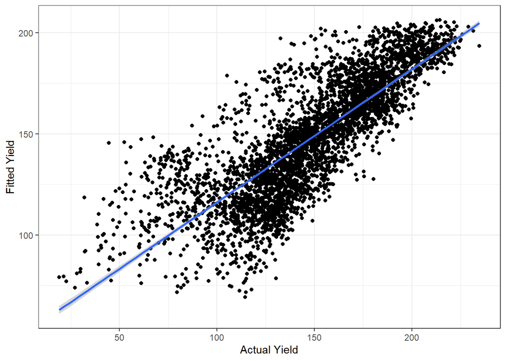

```r
panel$fitted <- lm_yield_county_combo$fitted.values

ggplot(panel)+
  geom_point(aes(x = yield, y = fitted)) +
  geom_smooth(aes(x = yield, y = fitted), method = lm) +
  xlab("Actual Yield")+
  ylab("Fitted Yield")+
  theme_bw()
```

### Question 5 – Soybeans: Download NASS data on soybean yields and explore either a time series relationship for a given county, the cross-sectional relationship for a given year, or a panel across all counties and years.

*For soybeans, the fitted values for yields less than about 40 overestimate the acutal yields, whereas values greater than 40 tend to underestimate the acutal yield values.*

```r
# set our API key with NASS
nassqs_auth(key = "F7506B86-1C9E-39F3-AA20-719CAD3B47A3")

# parameters to query on
paramssoy <- list(commodity_desc = "SOYBEANS", statisticcat_desc="YIELD", prodn_practice_desc = "ALL PRODUCTION PRACTICES", year__GE = 1981, state_alpha = "IA")

# download
soyyieldsall <- nassqs_yields(paramssoy)
soyyieldsall$county_ansi <- as.numeric(soyyieldsall$county_ansi)
soyyieldsall$yield <- as.numeric(soyyieldsall$Value)

# clean and filter this dataset
soyyields <- select(soyyieldsall, county_ansi, county_name, yield, year) %>%
  filter(!is.na(county_ansi) & !is.na(yield))
soyyields <- tibble(soyyields)

soyyields <- soyyieldsall %>% group_by(county_code) %>%
  unique() %>%
  filter(!is.na(county_ansi))

tmaxcountyall <- tmaxdf %>%  group_by(countyfp) %>%
  filter(doy >- 152 & doy <= 243) %>%
  summarize(meantmax = mean(tmax)) %>%
  rename(county_ansi = "countyfp")

tmaxcountyall$county_ansi <- as.numeric(as.character(tmaxcountyall$county_ansi))

panelsoy <- left_join(soyyields, tmaxcountyall, by = "county_ansi")

panelsoy$county_ansi <- as.factor(panelsoy$county_ansi)
panelsoy$tsq <- panelsoy$meantmax^2

lm_yield_county_combo <- lm(yield ~ meantmax + tsq + county_ansi + year, panelsoy)
summary(lm_yield_county_combo)
```

```
##
## Call:
## lm(formula = yield ~ meantmax + tsq + county_ansi + year, data = panelsoy)
##
## Residuals:
##      Min       1Q   Median       3Q      Max
## -25.5937  -2.7370   0.8253   3.6352  13.6087
##
## Coefficients: (2 not defined because of singularities)
##                  Estimate Std. Error t value Pr(>|t|)
## (Intercept)    -1.213e+03  1.288e+02  -9.420  < 2e-16 ***
## meantmax        2.513e+01  1.655e+01   1.519 0.128910
## tsq            -8.207e-01  5.320e-01  -1.543 0.122970
## county_ansi3   -9.045e-01  1.345e+00  -0.673 0.501152
## county_ansi5    4.654e-01  1.147e+00   0.406 0.684866
## county_ansi7   -4.638e+00  1.422e+00  -3.261 0.001120 **
## county_ansi9    1.801e+00  1.209e+00   1.490 0.136399
## county_ansi11   2.749e+00  1.320e+00   2.082 0.037370 *
## county_ansi13   1.754e+00  1.291e+00   1.358 0.174504
## county_ansi15   1.224e+00  1.256e+00   0.975 0.329812
## county_ansi17   1.831e+00  1.233e+00   1.485 0.137722
## county_ansi19   1.119e+00  1.251e+00   0.895 0.370965
## county_ansi21   1.115e+00  1.313e+00   0.849 0.395870
## county_ansi23   4.704e-01  1.288e+00   0.365 0.714942
## county_ansi25  -1.372e-05  1.324e+00   0.000 0.999992
## county_ansi27   1.882e+00  1.280e+00   1.470 0.141515
## county_ansi29   1.338e+00  1.238e+00   1.081 0.279972
## county_ansi31   5.178e+00  1.281e+00   4.041 5.42e-05 ***
## county_ansi33  -6.006e-01  1.106e+00  -0.543 0.587259
## county_ansi35   4.839e+00  1.332e+00   3.634 0.000282 ***
## county_ansi37  -1.061e+00  1.124e+00  -0.944 0.345006
## county_ansi39  -5.682e+00  1.330e+00  -4.274 1.97e-05 ***
## county_ansi41   1.851e-01  1.219e+00   0.152 0.879324
## county_ansi43   3.128e+00  1.229e+00   2.546 0.010943 *
## county_ansi45   4.157e+00  1.287e+00   3.230 0.001248 **
## county_ansi47   2.267e+00  1.268e+00   1.787 0.073955 .
## county_ansi49   1.555e+00  1.180e+00   1.318 0.187598
## county_ansi51  -2.886e+00  1.760e+00  -1.640 0.101094
## county_ansi53  -3.900e+00  1.537e+00  -2.538 0.011197 *
## county_ansi55   3.629e+00  1.228e+00   2.956 0.003133 **
```

[output cut: 63 more lines]

```
## county_ansi183  4.488e+00  1.286e+00   3.490 0.000489 ***
## county_ansi185 -5.174e+00  1.348e+00  -3.837 0.000126 ***
## county_ansi187  4.337e-01  1.323e+00   0.328 0.743060
## county_ansi189 -5.771e-01  1.121e+00  -0.515 0.606669
## county_ansi191 -7.552e-03  1.103e+00  -0.007 0.994540
## county_ansi193 -6.160e-01  1.222e+00  -0.504 0.614187
## county_ansi195         NA         NA      NA       NA
## county_ansi197         NA         NA      NA       NA
## year            5.330e-01  7.674e-03  69.451  < 2e-16 ***
## ---
## Signif. codes:  0 '***' 0.001 '**' 0.01 '*' 0.05 '.' 0.1 ' ' 1
##
## Residual standard error: 5.67 on 3898 degrees of freedom
## Multiple R-squared:  0.6082, Adjusted R-squared:  0.5983
## F-statistic: 61.12 on 99 and 3898 DF,  p-value: < 2.2e-16
```

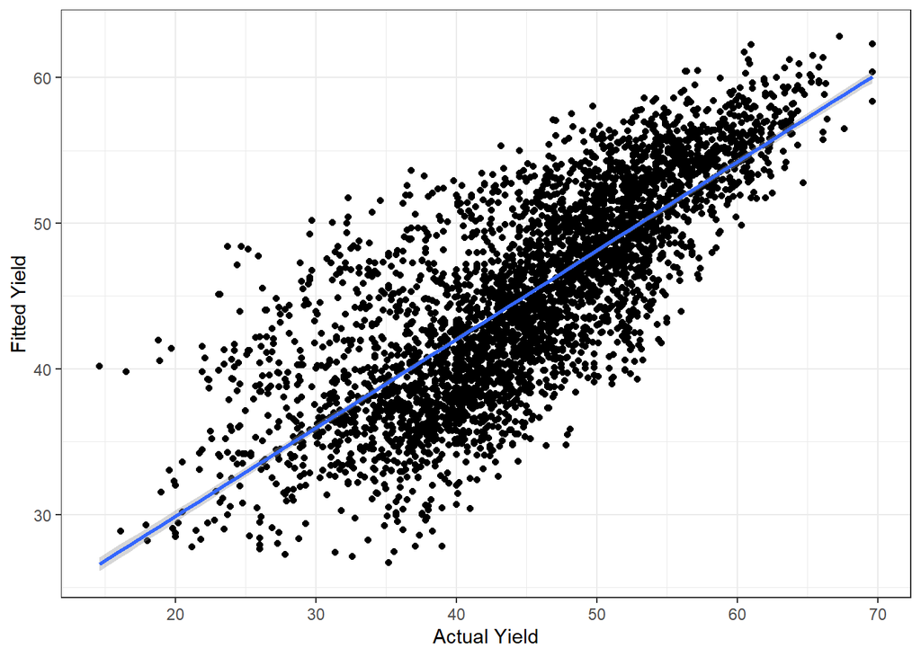

```r
panelsoy$fitted <- lm_yield_county_combo$fitted.values

ggplot(panelsoy)+
  geom_point(aes(x = yield, y = fitted)) +
  geom_smooth(aes(x = yield, y = fitted), method = lm) +
  xlab("Actual Yield")+
  ylab("Fitted Yield")+
  theme_bw()
```